# compliance_testing_1.0

Richard Leyshon

24/06/21

## 0.1 BLUF

- To see the accessibility check for this webpage, please visit [WAVE](https://wave.webaim.org/report#/https://datasciencecampus.github.io/DSCA_WCAG-2.1-Compliance/).
- Use `fig.cap` not `fig.alt` chunk option and tolerate duplicate text warning as suggested in literature.
- See alt text guidance.
- {Brailler} can automate descriptive chart alt text for **some** base and ggplots.
- Use chunk option `comment=""` to remove hashes preceding code output.

## 0.2 Plot Alt Text

```r
ggplot(data = pressure, aes(temperature, pressure)) +
  geom_point() +
  labs(title  = "Some placeholder title")
```

[output not shown]

```r
ggplot(data = pressure, aes(temperature, pressure)) +
  geom_point() +
  labs(title  = "Some placeholder title")
```

[output not shown]

Using the `fig.cap` chunk option avoids the issue with redundant title warning that comes with `fig.alt`. This provides a redundant text warning which I feel is more helpful than the redundant title warning for VI learners. Note that specifying the YAML option `fig_caption: false` does not resolve this issue, instead raising the redundant title warning again. This means [screen reader users will hear the text twice](https://r-resources.massey.ac.nz/rmarkdown/)

As advised by contractor on 2021 accessibility audit: Include blank alt text followed by the alt text in HTML p tag.

```r
ggplot(data = pressure, aes(temperature, pressure)) +
  geom_point() +
  labs(title  = "Some placeholder title")
```

[output not shown]

Joo Young Seo suggests the use of {BrailleR} (among others) for improving VI access of data & charts. Not published to CRAN at time of writing. Maintainer appears to be working on CRAN submission.

```r
# devtools::install_github("ajrgodfrey/BrailleR")
library(BrailleR)
```

```r
VI(ggplot(data = pressure, aes(temperature, pressure)) +
  geom_point() +
  labs(title  = "Some placeholder title"))
```

```
This chart has title 'Some placeholder title'.
It has x-axis 'temperature' with labels 0, 100, 200 and 300.
It has y-axis 'pressure' with labels 0, 200, 400, 600 and 800.
The chart is a set of 19 points.
```

### 0.2.1 Alt Text Structure

This section is mostly from Cesal, 2020 (see Resources).

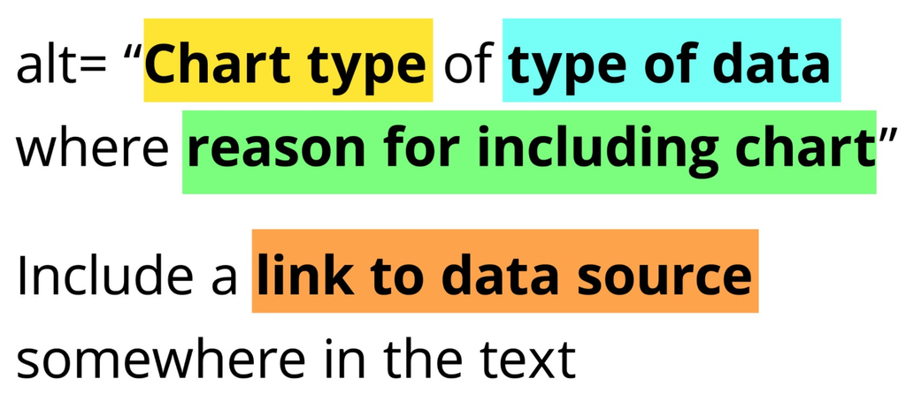

***

So for the following New york Times chart:

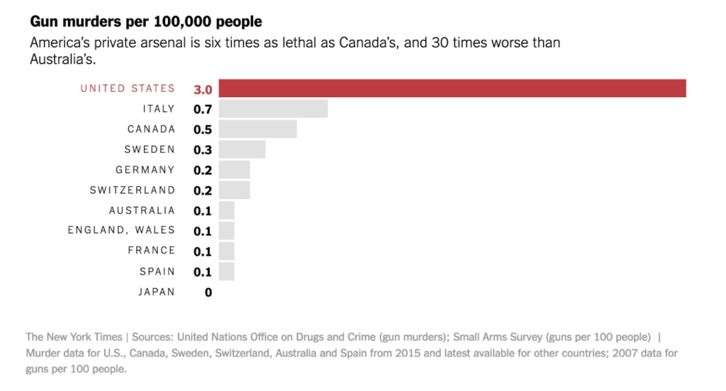

Alt text as below is suggested:

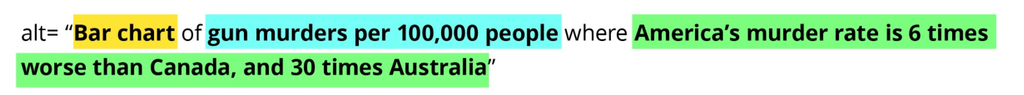

Or for a more complex chart, such as Warming Stripes, Hawkins:

[figure not shown]

Coloured stripes of chronologically ordered temperatures where they increase in red to show the warming global temperature

Alt text suggested:

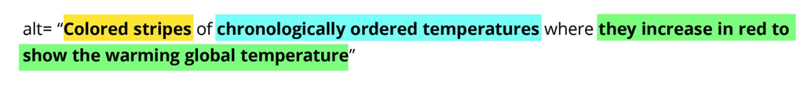

Suggested alt text for warming stripes image

## 0.3 Code Output

```r
# some unadjusted code with no chunk options
1:100
```

```
##   [1]   1   2   3   4   5   6   7   8   9  10  11  12  13  14  15  16  17  18
##  [19]  19  20  21  22  23  24  25  26  27  28  29  30  31  32  33  34  35  36
##  [37]  37  38  39  40  41  42  43  44  45  46  47  48  49  50  51  52  53  54
##  [55]  55  56  57  58  59  60  61  62  63  64  65  66  67  68  69  70  71  72
##  [73]  73  74  75  76  77  78  79  80  81  82  83  84  85  86  87  88  89  90
##  [91]  91  92  93  94  95  96  97  98  99 100
```

```r
# adjusted chunk options: `comment=""`, as recommended in Yihui see resources section.
1:100
```

```
  [1]   1   2   3   4   5   6   7   8   9  10  11  12  13  14  15  16  17  18
 [19]  19  20  21  22  23  24  25  26  27  28  29  30  31  32  33  34  35  36
 [37]  37  38  39  40  41  42  43  44  45  46  47  48  49  50  51  52  53  54
 [55]  55  56  57  58  59  60  61  62  63  64  65  66  67  68  69  70  71  72
 [73]  73  74  75  76  77  78  79  80  81  82  83  84  85  86  87  88  89  90
 [91]  91  92  93  94  95  96  97  98  99 100
```

Counterintuitively, the chunk option `comment=""` affects the chunk output rather than the appearance of code comments.

## 0.4 Resources

[Yihui, Rmarkdown cookbook](https://bookdown.org/yihui/rmarkdown-cookbook/html-accessibility.html)

[A. Jonathan R. Godfrey, 2018](https://r-resources.massey.ac.nz/rmarkdown/)

[Joo Young Seo, 2020](https://jooyoungseo.com/post/ds4blind/)

[Mock, 2021](https://themockup.blog/posts/2021-04-01-three-years-of-tidytuesday/#alt-text-for-graphs)

[Cesal, 2020](https://medium.com/nightingale/writing-alt-text-for-data-visualization-2a218ef43f81)

[Canelon & Hare, 2021](https://silvia.rbind.io/talk/2021-05-04-data-viz-accessibility/)

[Hawkins, Show Your Stripes](https://showyourstripes.info/)

## 0.5 To do

- Apply joint branding template.
- webpage regions - need greater control over YAML header / supplement with inline html
- Try Thom Mock’s alt text for charts implementation. Does this neatly fix the duplicate title / text issue.
- styling of chunk outputs
- header hierarchy - css to adjust author & date header titles
- header hierarchy - css to modify default appearance of h2s etc